# Statistikos laboratorinis darbas

Elijas Dapšauskas  
2019 m.

# Įvadas

### Žymėjimas

Dėl įskaitomumo ir patogumo, kode žymima:  
`X` - tiriamas atsitiktinis dydis (didysis X)  
`x` - tiriamo atsitiktinio dydžio imties realizacija (mažasis x)  
`xx` - tiriamo atsitiktinio dydžio imčių realizacijos  
`arg.x` - funkcijos argumentas x, kai turima omenyje ne a.d. X imties realizaciją (-as)

### R aplinkos paruošimas

Šiomis kodo eilutėmis paruošiama R aplinka laboratoriniame darbe esančiam kodui paleisti.

```r
# Nustotomas grafikų dydis
options(repr.plot.width=8, repr.plot.height=4)
# Fiksuojama atsitiktinių dydžių generatorių pradinė ("seed") reikšmė
set.seed(777)
# Įgalinamas lietuviškų diakritinių ženklų naudojimas grafikuose esančiuose tekstuose
invisible(Sys.setlocale(locale="lithuanian"))
# Įrašomos ir iškviečiamos naudojamos bibliotekos
if (!require(pracma)) install.packages("pracma")
suppressWarnings(library(pracma))
if (!require(sm)) install.packages("sm")
library(sm)
library(stringr)
```

# 1. Pseudoatsitiktinių dydžių generavimas

## 1.1. Atsitiktinių dydžių generavimas naudojant tiesinį kongruentinį algoritmą

[figure not shown]

Šis iteracinis generavimo algoritmas gali būti implementuotas įvairiais būdais. Čia pasirinktas rekursinis algoritmas, tinkantis su nedidelėmis $n$ reikšmėmis.

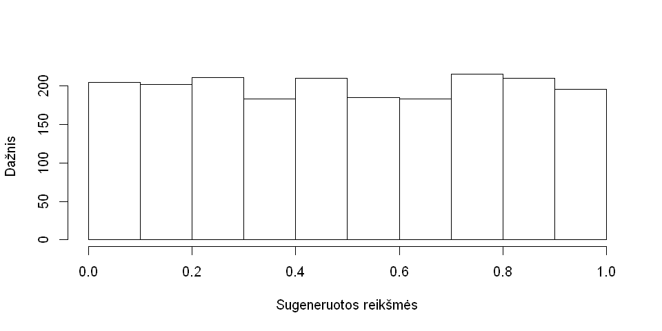

```r
random.uniform = function(n, seed=12, a=7^5, c=0, m=2^32-1, output=c(seed)) {
    if (length(output) == n)  # Algoritmo pabaiga (tikrinama terminavimo sąlyga)
        return(output / m)  # Mažinamas reikšmių intervalas iš [0;m) į [0;1)

    new_value = (a * seed + c) %% m  # Tiesinis kongruentinis algoritmas

    return(Recall(seed=new_value, output=append(output, new_value), n=n, a=a, c=c, m=m))
}

# Tinkamą atsiktinių dydžių pasiskirstymą demonstruosime histograma
x.size = 2e3
x = random.uniform(n=x.size)
hist(x, ylab="Dažnis", xlab="Sugeneruotos reikšmės", main="")
```

## 1.2. Atsitiktinių dydžių generavimas atvirkštinės funkcijos metodu

[figure not shown]

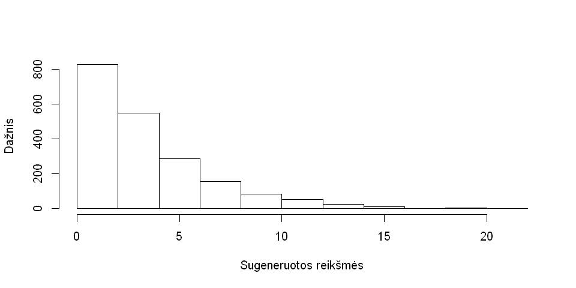

```r
const.seed = 123

random.exponential = function(lambda, n, seed) {
    realization.uniform = random.uniform(n, seed)
    return(-log(1 - realization.uniform) / lambda)  # Naudojama atvirkštinė eksponentinei f-ja
}

# Tinkamą atsiktinių dydžių pasiskirstymą demonstruosime histograma
X.lambda = .3
x.size = 2e3
x = random.exponential(n=x.size, lambda=X.lambda, seed=const.seed)
hist(x, ylab="Dažnis", xlab="Sugeneruotos reikšmės", main="")
```

# 2. Parametrų vertinimas Monte Carlo metodu

## 2.1. Skaičiaus pi vertinimas statistiniu būdu

[figure not shown]

Turime kvadratą su viršūnėmis $(-1,-1)$ ir $(1, 1)$ ir jame įbrėžtą apskritimą. Šiame plote tolygiu pasiskirstymu atsitiktinėse vietose padėsime taškus. Laikysime, kad taškų skaičiaus patenkančio į plotą santykis su visu taškų skaičiumi aproksimuoja to ploto santykį su visu kvadratu. Plotų, kuriuos riboja apskritimas ir kvadratas, santykis lygus $\frac{π}{4}$, todėl ieškodami pi reikšmės apskaičiuotą santykį dauginsime iš $4$.

##### Pi įverčio radimo funkcijos implementacija

```r
estimate_pi = Vectorize(function(points.count) {
    # Kvadrate padėtų taškų x ir y komponenčių generavimas
    points.x = runif(points.count, -1, 1)
    points.y = runif(points.count, -1, 1)

    # Apskaičiuojamas atenkančių į apskritimą taškų kiekio santykis
    points.inside.count = sum(points.x ^ 2 + points.y ^ 2 <= 1)
    points.inside.ratio = points.inside.count / points.count

    # Pi įverčio gavimas
    pi.estimate = points.inside.ratio * 4
    return(pi.estimate)
})

estimate_pi(points.count = 1e6)  # Funkcija išbandoma
```

3.140264

##### Grafiniu būdu stebimas pi įverčio konvergavimas didėjant modeliavimo taškų kiekiui

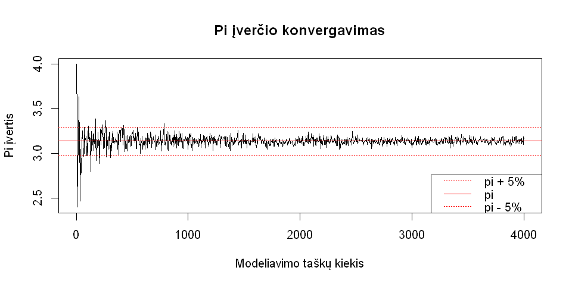

```r
curve.pts = curve(estimate_pi, from = 2, to = 4e3, n = 1000,
                  ylab="Pi įvertis",
                  xlab="Modeliavimo taškų kiekis",
                  main="Pi įverčio konvergavimas")
abline(h=pi, col="red")

# Pažymėsime 5% santykinės paklaidos ribas
abline(h=pi * (1 + .05), col="red", lty = 3)
abline(h=pi * (1 - .05), col="red", lty = 3)
legend("bottomright", lty = c(3, NA, 1, NA, 3),
       legend = c("pi + 5%", NA, "pi", NA, "pi - 5%"), col="red")
```

##### Grafiniu būdu stebima santykinė paklaida didėjant modeliavimo taškų kiekiui

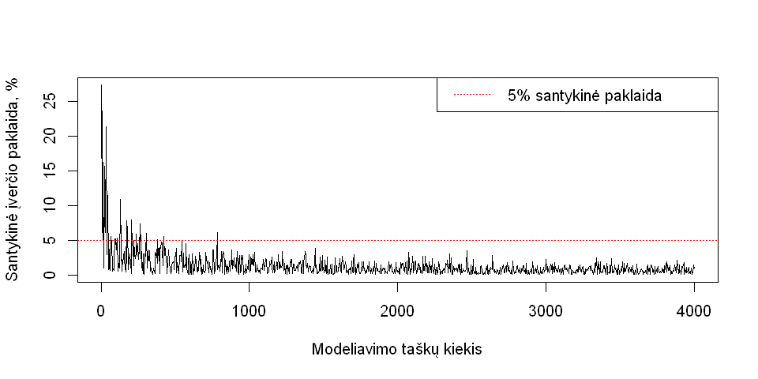

```r
pi.estimates = curve.pts$y
pi.estimates.rel_err_pct = 100 * abs(pi.estimates - pi) / pi

plot(curve.pts$x, pi.estimates.rel_err_pct, type='l', main="",
     xlab="Modeliavimo taškų kiekis", ylab="Santykinė įverčio paklaida, %")
legend("topright", lty = c(NA, 3, NA), legend = c(NA, "5% santykinė paklaida", NA), col="red")
abline(h=5, col="red", lty=3)
```

##### Pakankamo modeliavimo taškų kiekio paieška pakankamai tikslaus įverčio gavimui

Panašu, jog $n = 800$ yra pakankamas, kad santykinė paklaida daugiau nei $99\%$ atvejų būtų mažesnė už $5\%$. Patikrinsime su $m = 10^4$ atvejų.

```r
points.count = 800  # Modeliavimo taškų kiekis
experiments.count = 1e4  # Kiekis bandymų siekiant išsiaiškinti, kiek iš jų pateikia įverčius santykinės paklaidos ribose

# Atliekamas eksperimentas
pi.estimates = replicate(experiments.count, estimate_pi(points.count))

# Analizuojami eksperimento duomenys. Skaičiuojame, kiek kartų sant. pakl. neviršyjo ribos ir daliname iš visų atvejų. Gauname santykį išreikštą procentais.
experiments.positive.count = sum(abs(pi.estimates - pi) / pi < .05)
experiments.positive.ratio_pct = experiments.positive.count / experiments.count * 100
cat(experiments.positive.ratio_pct, "%", sep = '')
```

```
99.24%
```

Patvirtinta.

# 3. Empirinės charakteristikos

## 3.1. Empirinė tikimybių pasiskirstymo funkcija

[figure not shown]

```r
const.epsilon = 1e-9

X.mean = 10
X.variance = 9
X.sd = sqrt(X.variance)
x.size = 100
x.realize = function(count=1) replicate(count, rnorm(n = x.size, mean = X.mean, sd = X.sd), simplify = count == 1)
X.cdf = Vectorize(function(arg.x) pnorm(arg.x, X.mean, X.sd))
```

##### Sudaroma empirinės tikim. pasiskirstymo funkcijos realizacija

```r
x = x.realize()
x.ecdf = ecdf(x)

# Sukurta funkcija, skirta apskaičiuoti e. t. p. f. reikšmę taške x pagal duotą formulę
Fn = function(arg.x, X.sample) sum(X.sample <= arg.x) / x.size
Fn(X.mean, x)  # Funkcija išbandoma
```

0.55

##### Duotų tikimybių įverčių radimas

```r
# Apibrėžiami pagalbiniai keitiniai siekiant padaryti kodą įskaitomesnį
print_equality = function(lhs, rhs, prefix="", lhs.width=15)
    cat(prefix, " ", str_pad(lhs, lhs.width, "left"), " = ", rhs, "\n", sep = "")
e = const.epsilon

print_equality("P{X <= 10}", Fn(10, x))
# Keičiame griežtą nelygybės apibžrėžimą į negriežtą naudodami P{X < 10} = P{X <= 10-e}, kur e yra nykstamai mažas dydis
print_equality("P{X < 10}", Fn(10-e, x))
# Pagal P{0 <= X <= 10} = P{X <= 10} - P{X < 0} = P{X <= 10} - P{X <= 0-e}
print_equality("P{0 <= X <= 10}", Fn(10, x) - Fn(0-e, x))
```

```
      P{X <= 10} = 0.55
       P{X < 10} = 0.55
 P{0 <= X <= 10} = 0.55
```

##### Nubraižomos empirinė ir teorinė pasiskirstymo funkcijos

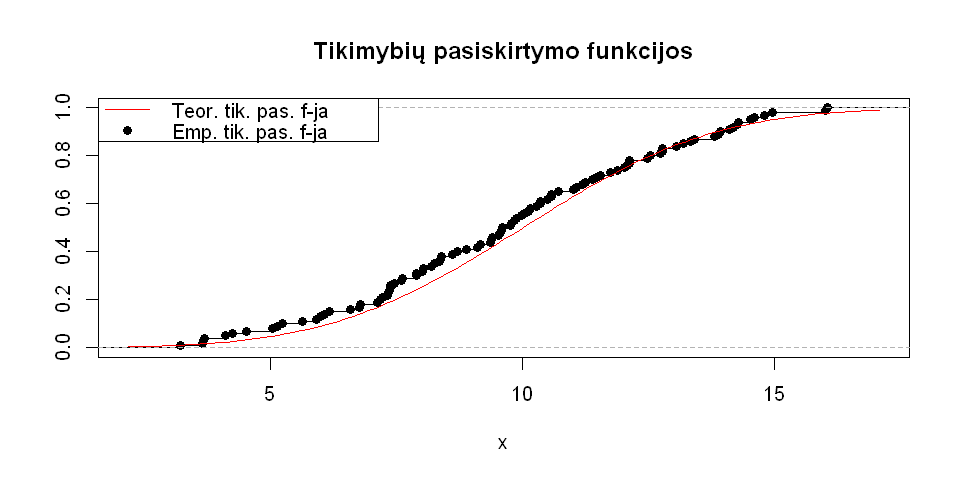

```r
plot(x.ecdf, main="Tikimybių pasiskirtymo funkcijos", ylab="")
curve(X.cdf, add=T, col='red')
legend("topleft", lty = c(1, NA, NA), pch=c(NA, NA, 16),
       legend = c("Teor. tik. pas. f-ja", NA, "Emp. tik. pas. f-ja"), col=c("red", NA, "black"))
```

## 3.2. Empiriniai kvantiliai ir pozicinės statistikos

[figure not shown]

##### Apibrėžiami atsitiktinio dydžio parametrai ir funkcijos

```r
k = 10
# k reikšmė, pagal kurią realizuosime k-ąją pozicinę statistiką

X.min = 0
X.max = 1
X.pdf = Vectorize(function(x) dunif(x, min = X.min, max = X.max))
X.cdf = Vectorize(function(x) punif(x, min = X.min, max = X.max))

x.size = 20
x.realize = function(count=1) replicate(count, runif(n = x.size, min = X.min, max = X.max), simplify = count == 1)
```

##### Užrašoma k-osios pozicinės statistikos pas. f-jos išraiška

Iš užduoties aprašymo žinome: $$F_{X_{(k)}}(x)=\textbf{P}\{X_{(k)}\leqslant x\}=\textbf{P}\{Y \geqslant k\} = \sum\limits_{j=k}^n \binom{n}{j} F(x)^j \big(1-F(x)\big)^{n-j}$$

$F_{X_{(k)}}(x)$ implementuojamas su `cdf_k()`

```r
cdf_k = function(arg.x, cdf, n, k) {
    # Kadangi pasiskirstymo funkcija yra suma, galime apibrėžti funkciją rasti jos dėmeniui (angl. summand)
    summand = Vectorize(function(j) choose(n, j)  *  cdf(arg.x)^j  *  (1 - cdf(arg.x))^(n - j))
    return(sum(summand(k:n)))
}
x.k.cdf = function(arg.x) cdf_k(arg.x = arg.x, cdf = X.cdf, n = x.size, k = k)

lhs.width = 21
print_equality(prefix="a)", lhs = "P{X_(k) <= 1/4}", lhs.width = lhs.width,
               rhs = x.k.cdf(1/4))
print_equality(prefix="b)", lhs = "P{X_(k) > 1/2}", lhs.width = lhs.width,
               rhs = 1 - x.k.cdf(1/2))
print_equality(prefix="c)", lhs = "P{1/3 < X_(k) <= 1/2}", lhs.width = lhs.width,
               rhs = x.k.cdf(1/2) - x.k.cdf(1/3))
```

```
a)       P{X_(k) <= 1/4} = 0.01386442
b)        P{X_(k) > 1/2} = 0.4119015
c) P{1/3 < X_(k) <= 1/2} = 0.4962028
```

##### Braižoma k-osios pozicinės statistikos histograma

Iš kiekvienos imties išrenkama k-osios poz. stat. realizacija ir nubraižoma histograma bei teorinio tankio funkcija.

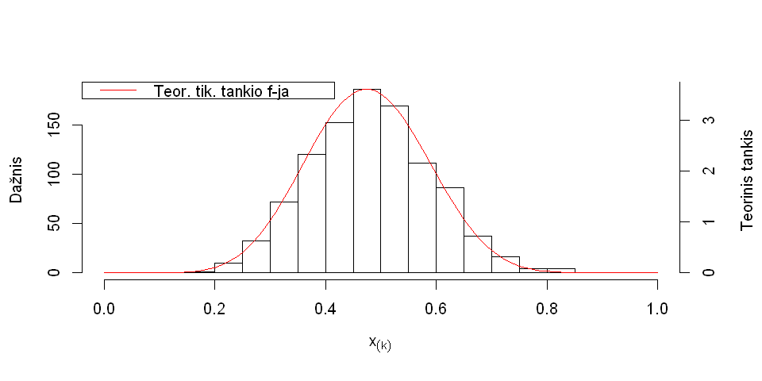

```r
# Sugeneruosime m imčių po n elementų, iš kiekvienos išrinksime k-osios poz. stat. realizaciją ir nubraižysime histogramą.
xx.count = 1000
xx = x.realize(xx.count)
xx.k = Vectorize(function(x) sort(x)[k])(xx)

par(mar = c(5, 4, 4, 4) + .3)  # Paliekame vietos z ašiai
h = hist(xx.k, breaks=seq(0, 1, .05),
         main="", ylab="Dažnis", xlab=expression(x[(k)]))


# Užrašoma ir nubrėžiama teorinio tankio funkcija
pdf_k = function (arg.x, n, k, pdf, cdf) n * pdf(arg.x) * choose(n-1, k-1) * cdf(arg.x)^(k-1) * (1-cdf(arg.x))^(n-k)
x.k.pdf = Vectorize(function(arg.x) pdf_k(arg.x = arg.x, cdf=X.cdf, pdf=X.pdf, n=x.size, k=k))

par(new = T)  # Brėšime į jau esantį grafiką
plot.y = x.k.pdf(seq(0, 1, .01))
plot(plot.y, type='l', axes = FALSE, bty = "n", xlab = "", ylab = "", col = "red")
axis(side = 4, at = pretty(range(plot.y)))
mtext("Teorinis tankis", side = 4, line = 3)
legend("topleft", lty = c(1), col="red", legend = c("Teor. tik. tankio f-ja"))
```

##### Teorinio k-osios poz. stat. vidurkio palyginimas su empiriniu vidurkiu

```r
find_mean_from_pdf = function(pdf) integrate(f = function(x) x * pdf(x), lower = -Inf, upper = Inf)$value

# Pademonstruojame, kad funcija veikia tinkamai rasdami a.d., tolygiai pasiskirsčiusio [0,1], vidurkį lygų 0.5
stopifnot(find_mean_from_pdf(dunif) == 0.5)
```

```r
theoretical_mean = find_mean_from_pdf(x.k.pdf)
empirical_mean = mean(xx.k)

cat("Teorinis vidurkis:", theoretical_mean, "\n")
cat("Empirinis vidurkis:", empirical_mean, "\n")
cat("Absoliutus vidurkių skirtumas: ", abs(theoretical_mean - empirical_mean), "\n")
cat("Santykinė emp. vid. paklaida nuo teor. vid.: ", abs(theoretical_mean - empirical_mean) / theoretical_mean, sep = "", "\n")
```

```
Teorinis vidurkis: 0.4761905
Empirinis vidurkis: 0.4817424
Absoliutus vidurkių skirtumas:  0.005551969
Santykinė emp. vid. paklaida nuo teor. vid.: 0.01165913
```

## 3.3. Nukirstas vidurkis

[figure not shown]

##### Apibrėžiami atsitiktinio dydžio parametrai ir funkcijos, išsaugomos konstantos iš sąlygos

```r
X.mean = 0
X.sd = 1
X.pdf = Vectorize(function(x) dnorm(x, mean = X.mean, sd = X.sd))
X.cdf = Vectorize(function(x) pnorm(x, mean = X.mean, sd = X.sd))
x.size = 100
x.mean.pdf = Vectorize(function(x) dnorm(x, mean = X.mean, sd = X.sd / sqrt(x.size)))
x.realize = function(count=1) replicate(count, rnorm(n = x.size, mean = X.mean, sd = X.sd), simplify = count == 1)
xx.count = 1000

const.p = .2
const.k = const.p * x.size
plot.const.x.min = -X.sd / 2
plot.const.x.max = X.sd / 2
plot.const.x.bars = 20
```

##### Apibrėžiamos pagalbinės funkcijos

```r
truncate_sample = function(x, k) sort(x)[(k + 1):(length(x) - k)]
truncate_samples = function(k) Vectorize(function(x) truncate_sample(x, k), SIMPLIFY = F)

stopifnot(identical(
    truncate_samples(k=1)(x=list(c(1,2,3,4,5), c(3,4,5,6,7))),
    list(c(2,3,4), c(4,5,6))
))
```

```r
winsorize_sample = function(lst, k) {
    n = length(lst)
    lst = sort(lst)
    lst[1:k] = lst[k+1]
    lst[(n-k+1):n] = lst[n-k]
    return(lst)
}
winsorize_samples = function(k) Vectorize(function(x) winsorize_sample(x, k), SIMPLIFY = F)

stopifnot(identical(
    winsorize_samples(k=1)(x=list(c(1,2,3), c(3,4,5))),
    list(c(2,2,2), c(4,4,4))
))
```

##### Apibrėžiamas vykdomas eksperimentas

```r
run_experiment = function(xx, transform_samples_function) {
    xx.transformed = transform_samples_function(xx)
    xx.transformed.mean = Vectorize(function(arg.x) mean(arg.x))(xx.transformed)

    # Brėžiama transformuotų vidurkių histograma
    par(mar = c(5, 4, 4, 4) + .3)  # Paliekame vietos z ašiai
    hist(xx.transformed.mean, main="", ylab="Dažnis", xlab=expression(bar(x)),
         breaks=seq(plot.const.x.min, plot.const.x.max, length.out=plot.const.x.bars))

    # Brėžiamas teorinio empirinio vidurkio tankio f-jos grafikas
    par(new = T)  # Brėšime į jau esantį grafiką
    plot.y = x.mean.pdf(seq(plot.const.x.min, plot.const.x.max, length.out = 100))
    plot(plot.y, type='l', axes = FALSE, bty = "n", xlab = "", ylab = "", col = "red")
    axis(side = 4, at = pretty(range(plot.y)))
    mtext("Teorinis tankis", side = 4, line = 3)
    legend("topleft", lty = c(1), col="red", legend = c("Teor. emp. vidurk. tank."))

    # Apskaičiuojamas transformuoto vidurkio: vidurkis ir dispersija
    return(data.frame(
        transformed_mean_mean=mean(xx.transformed.mean),
        transformed_mean_variance=var(xx.transformed.mean)
    ))
}
```

```r
xx = x.realize(xx.count)
```

##### Atliekamas experimentas su nukirstu vidurkiu

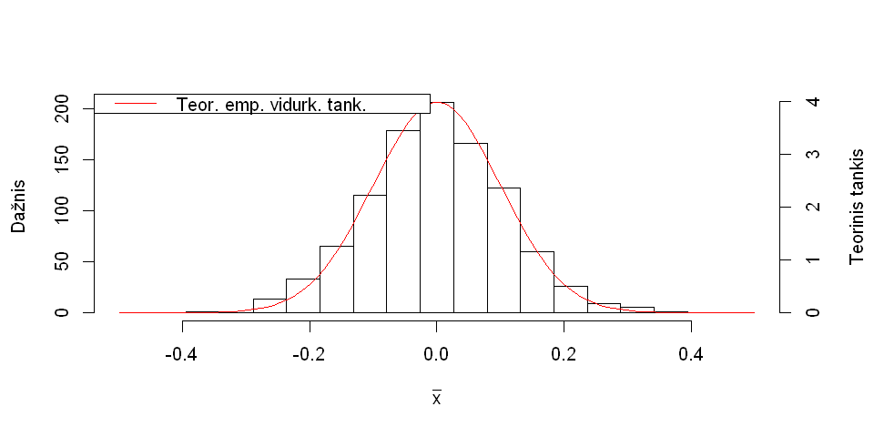

```r
truncate.experiment = run_experiment(xx, transform_samples_function = truncate_samples(k=const.k))
```

##### Atliekamas experimentas su vinzorizuotu vidurkiu

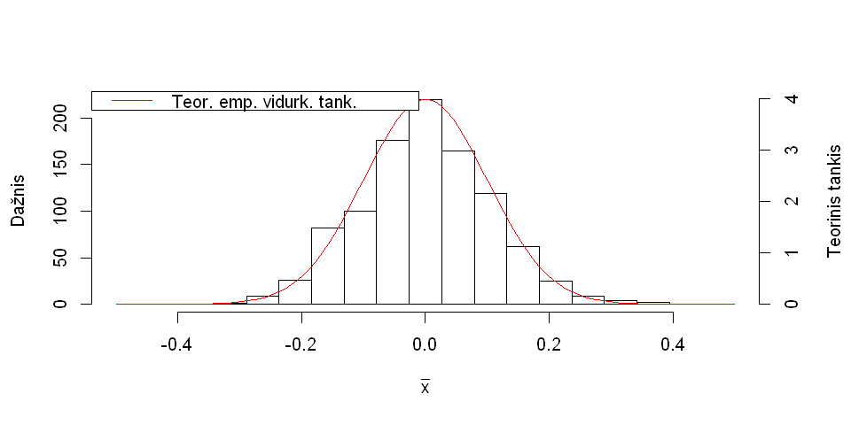

```r
winsorize.experiment = run_experiment(xx, transform_samples_function = winsorize_samples(k=const.k))
```

##### Vidurkių palyginimas

```r
xx.mean = Vectorize(function(arg.x) mean(arg.x))(xx)

cat("Teorinis vidurkis:",
    X.mean, "\n")
cat("Vidurkių vidurkis:",
    mean(xx.mean), "\n")
cat("Nukirstų vidurkių vidurkis:",
    truncate.experiment$transformed_mean_mean, "\n")
cat("Vinzorizuotų vidurkių vidurkis:",
    winsorize.experiment$transformed_mean_mean, "\n")
```

```
Teorinis vidurkis: 0
Vidurkių vidurkis: -4.702841e-05
Nukirstų vidurkių vidurkis: -0.0004476584
Vinzorizuotų vidurkių vidurkis: -0.0001750789
```

##### Transformuotų vidurkių empirinių dispersijų palyginimas

```r
t.e.tmv = truncate.experiment$transformed_mean_variance
w.e.tmv = winsorize.experiment$transformed_mean_variance

cat("Nukirsto vidurkio dispersija:", t.e.tmv, "\n")
cat("Vinzorizuoto vidurkio dispersija:", w.e.tmv, "\n")
if (t.e.tmv > w.e.tmv) {cat("Nukirsto vidurkio dispersija didesnė")
} else if (t.e.tmv < w.e.tmv) {cat("Vinzorizuoto vidurkio dispersija didesnė")
} else {cat("Dispersijos lygios")}
```

```
Nukirsto vidurkio dispersija: 0.01137008
Vinzorizuoto vidurkio dispersija: 0.01103233
Nukirsto vidurkio dispersija didesnė
```

## 3.4. Branduolinis tankio įvertis

[figure not shown]

##### Apibrėžiamos konstantos, atsitiktinio dydžio parametrai ir funkcijos

```r
const.z = .5

X.mean = 0
X.sd = 1
X.pdf = Vectorize(function(arg.x) dnorm(arg.x, mean = X.mean, sd = X.sd))
x.size = 50
xx.count = 100
xx = replicate(xx.count, rnorm(n = x.size, mean = X.mean, sd = X.sd), simplify = xx.count == 1)
```

##### Implementuojama f-ja gauti branduolinį įvertį pgl. duotą formulę

```r
estimate_kernel_density = function(z, x, h, kernel) {
    summand = Vectorize(function(x.i)  kernel((z - x.i) / h)  )
    return(sum(summand(x)) / (length(x) * h))
}

# estimate_kernel_density f-jai pritaikomas vektorizuotas kintamųjų iškėlimas (angl. currying)
ekd.curried = function(z, kernel)
                Vectorize(function(h)
                Vectorize(function(x)
                estimate_kernel_density(z, x, h, kernel)))

kernel.uniform = function(arg.x) (abs(arg.x) <= 1) / 2  # Tolygusis branduolys
kernel.gaussian = function(arg.x) exp(-arg.x ^ 2 / 2) / sqrt(2 * pi)  # Gauso branduolys
```

Patikrinama, ar funkcija `estimate_kernel_density()` implementuota tinkamai, lyginant ją su `density()` f-ja iš standartinės bibliotekos.

Laikysime, kad tinkamai, jei su glodinimo parametru $h_n = 2.5$, apskaičiuotas tankis $512$ tolygiai pasiskirsčiusių taškų reikšmių intervale $[-10, 10]$ skirsis vienas nuo kito ne daugiau nei $10^{-3}$.

```r
x = xx[[1]]
h = 2.5
z.min = -10
z.max = 10
z.count = 512

kde.official = density(x = x, kernel = "gaussian", bw=h, n=z.count, from=z.min, to=z.max)$y

zz = seq(from=z.min, to=z.max, length.out = z.count)
ekd.zz = function(x, h, kernel) Vectorize(function(z) estimate_kernel_density(z, x, h, kernel))
kde.my_own = ekd.zz(x, h, kernel.gaussian)(zz)

stopifnot(all(abs(kde.official - kde.my_own) <= 1e-3))
```

##### Modeliavimo būdu ištiriama tankio funkcijos vertinimo tikslumo priklausomybė nuo $h_n$

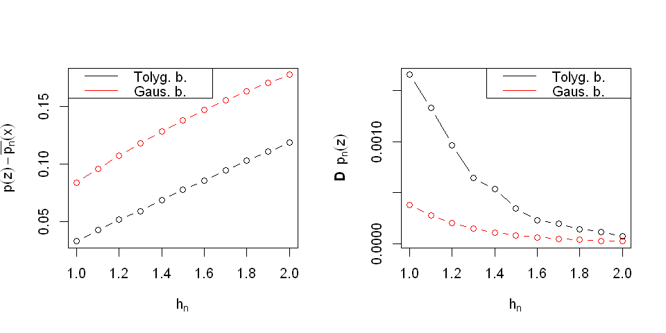

```r
hh = seq(from = 1, to = 2, by = .1)

kde.with_kernel = function(kernel) lapply(ekd.curried(z=const.z, kernel=kernel)(h=hh), function(f) f(x=xx))
kde.uniform = kde.with_kernel(kernel.uniform)
kde.gaussian = kde.with_kernel(kernel.gaussian)

par(mfrow = c(1,2)) # Grafikai brėžiami vienas šalia kito

# Brežiamas pirmasis grafikas
kde.uniform.means_diff = X.pdf(const.z) - sapply(kde.uniform, mean)
kde.gaussian.means_diff = X.pdf(const.z) - sapply(kde.gaussian, mean)
plot.mean.y.min = min(kde.uniform.means_diff, kde.gaussian.means_diff)
plot.mean.y.max = max(kde.uniform.means_diff, kde.gaussian.means_diff)

plot(hh, kde.uniform.means_diff, type='b', main="",
     xlab=expression(h[n]), ylab=expression(p(z) - bar(p[n])(x)),
     ylim=c(plot.mean.y.min, plot.mean.y.max))
lines(hh, kde.gaussian.means_diff, type='b', col="red")
legend("topleft", lty = 1, legend = c("Tolyg. b.", NA, "Gaus. b."), col=c("black", NA, "red"))


# Brežiamas antrasis grafikas
kde.uniform.variance = sapply(kde.uniform, var)
kde.gaussian.variance = sapply(kde.gaussian, var)
plot.variance.y.min = min(kde.uniform.variance, kde.gaussian.variance)
plot.variance.y.max = max(kde.uniform.variance, kde.gaussian.variance)

plot(hh, kde.uniform.variance, type='b', main="",
     xlab=expression(h[n]), ylab=expression(bold(D)~~p[n](z)),
     ylim=c(plot.variance.y.min, plot.variance.y.max))
lines(hh, kde.gaussian.variance, type='b', col="red")
legend("topright", lty = 1, legend = c("Tolyg. b.", NA, "Gaus. b."), col=c("black", NA, "red"))
```

Iš grafikų matome, kad didinant glodinimo parametrą $h_n$, skirtumas tarp vidurkių didėja, tačiau dispersija mažėja (kitaip sakant, $p_n(z)$ reikšmės vis labiau susitelkia vienoje vietoje, tačiau vidurkis tolsta nuo tikrojo). Tokį patį efektą turi ir Gauso branduolio naudojimas vietoj tolygiojo.

# 4. Statistinio modelio parametrų vertinimo metodai

## 4.1. Momentų metodas

[figure not shown]

##### Apibrėžiama imtis, atsitiktinio dydžio parametrai ir funkcijos

```r
const.theta = 10

X.min = 0
X.max = const.theta
X.pdf = Vectorize(function(arg.x) dunif(arg.x, min = X.min, max = X.max))
x.size = 20
xx.count = 1000
xx = replicate(xx.count, runif(n = x.size, min = X.min, max = X.max), simplify = xx.count == 1)
```

##### a) Metodas 1: Parametro $\theta$ įvertis gaunamas per pirmosios eilės pradinį momentą

Pasiskirtymo parametras $\theta$ susiejamas su paprastąja atsitiktine imtimi $X$ per pirmosios eilės pradinį momentą $\textbf{E}\xi $ ir išreiškiama įvertinio gavimo formulė.

$$\textbf{E}\xi = \frac{a+b}{2} = \frac{0+\theta}{2} \implies \theta = 2\, \textbf{E} \xi \implies \theta' = 2 \overline{X}$$

```r
est_theta.method1 = function(x) 2 * mean(x)
est_theta.method1(xx[[1]])  # Pademonstruojamas theta įverčio gavimas iš vienos imties
```

9.59000150905922

##### b) Metodas 2: Parametro $\theta$ įvertis gaunamas per antrosios eilės pradinį momentą

Pasiskirtymo parametras $\theta$ susiejamas su paprastąja atsitiktine imtimi $X$ per antrosios eilės pradinį momentą $\textbf{E}\xi^2 $ ir išreiškiama įvertinio gavimo formulė.

$$\textbf{E}\xi^2 = \frac{a^2+ab+b^2}{3} = \frac{0^2+0\cdot\theta+\theta^2}{3} \implies \theta = \sqrt{3\, \textbf{E} \xi^2} \implies \theta' = \sqrt{3\, \overline{X^2}}$$

```r
est_theta.method2 = function(x) sqrt(3 * mean(x^2))
est_theta.method2(xx[[1]])  # Pademonstruojamas theta įverčio gavimas iš vienos imties
```

9.94561303715656

##### c) Metodas 3: Parametro $\theta$ įvertis gaunamas per antrosios eilės centrinį momentą

Pasiskirtymo parametras $\theta$ susiejamas su paprastąja atsitiktine imtimi $X$ per antrosios eilės centrinį momentą $\mu_2(\xi) $ ir išreiškiama įvertinio gavimo formulė.

$$\mu_2(\xi) = \frac{(b-a)^2}{12} = \frac{(\theta - 0)^2}{12} \implies \theta = \sqrt{12\, \mu_2(\xi)} \implies \theta' = \sqrt{12\, \mathbf{s}(X)}$$

```r
est_theta.method3 = function(x) sqrt(12 * var(x))
est_theta.method3(xx[[1]])  # Pademonstruojamas theta įverčio gavimas iš vienos imties
```

11.2276204494077

##### Vertinamas geriausias metodas pagal įverčių vidurkį ir dispersiją

```r
est_theta.methods = list(est_theta.method1, est_theta.method2, est_theta.method3)
methods.theta_est = lapply(est_theta.methods, function(method) sapply(xx, method))
methods.theta_est.mean = lapply(methods.theta_est, mean)
methods.theta_est.mean_abs_err = lapply(methods.theta_est.mean, function(m) abs(m - const.theta))
methods.theta_est.var = lapply(methods.theta_est, var)

cat("Kiekvienu metodu gautų theta įverčių vidurkiai:\n")
methods.theta_est.mean
cat("Kiekvienu metodu gautų theta įverčių dispersijos:\n")
methods.theta_est.var
cat("Geriausias metodas pagal vidurkį:", which.min(methods.theta_est.mean_abs_err), "\n")
cat("Geriausias metodas pagal dispersiją:", which.min(methods.theta_est.var), "\n")
```

```
Kiekvienu metodu gautų theta įverčių vidurkiai:
```

1. 9.95212724354607

2. 9.91369846565617

3. 9.94791781500004

```
Kiekvienu metodu gautų theta įverčių dispersijos:
```

1. 1.66879591178978

2. 1.02636001708862

3. 1.13597484429152

```
Geriausias metodas pagal vidurkį: 1
Geriausias metodas pagal dispersiją: 2
```

##### Brėžiamas branduolinis įvertinio $\hat{\theta}$ tankis

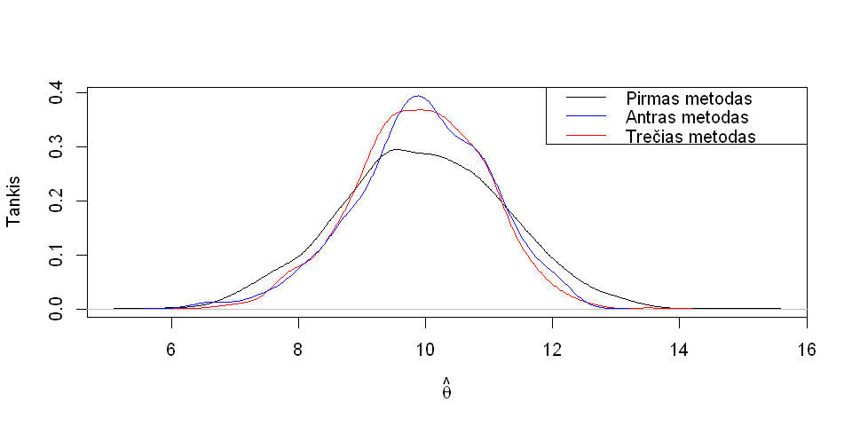

```r
methods.theta_est.density = lapply(methods.theta_est, density)
plot.y.min = min(sapply(methods.theta_est.density, function(d) min(d$y)))
plot.y.max = max(sapply(methods.theta_est.density, function(d) max(d$y)))

plot(methods.theta_est.density[[1]], ylab="Tankis", main="",
     xlab=expression(hat(theta)), ylim=c(plot.y.min, plot.y.max))
lines(methods.theta_est.density[[2]], col="red")
lines(methods.theta_est.density[[3]], col="blue")
legend("topright", legend = c("Pirmas metodas", NA, "Antras metodas", NA, "Trečias metodas"),
       lty=c(1,NA,1,NA,1), col=c(1,"red","blue"))
```

Iš grafiko matome, kad pirmuoju metodu rasti įverčiai labiau pasklidę tolyn nuo tikrosios $\theta$ reikšmės. Tuo tarpu kiti metodai pateikia daugiau reikšmių, artimesnių tikrąjai.

## 4.2. Didžiausio tikėtinumo metodas

[figure not shown]

##### Apibrėžiama imtis, atsitiktinio dydžio parametrai ir funkcijos

```r
X.lambda = 6
x.size = 20
x = rpois(n = x.size, lambda = X.lambda)
lambda_est.min = 0
lambda_est.max = 25
```

##### Implementuojama `loglikpois()` funkcija

```r
loglikpois = function(lambda, x) sum(Vectorize(function(x.i) dpois(x.i, lambda = lambda, log = T))(x))
loglikpois.lambda = Vectorize(function(lambda) loglikpois(lambda, x))
```

##### Analiziniu būdu gaunamas $\hat{\lambda}$ įvertis

Ieškomas logtikėtinumo funkcijos ekstremumas (maksimumas), pagal $\lambda$. Šiame maksimume, $\lambda$ reikšmė yra ieškomasis įvertinys. Maksimumui rasti, ieškosime sprendinio lygčiai $\frac{\partial l(\lambda, x)}{\partial \lambda} = 0$.

$$\frac{\partial l(\lambda, x)}{\partial \lambda} = \frac{\partial}{\partial \lambda} \sum\limits_{i=1}^n \ln p(x_i,\lambda) = \sum\limits_{i=1}^n \frac{\partial}{\partial \lambda} \ln \frac{\lambda^{x_i} e^{-\lambda}}{x_i!} = \sum\limits_{i=1}^n \bigg( \frac{x_i}{\lambda} - 1 \bigg) = \frac{1}{\lambda} \sum\limits_{i=1}^n \big(x_i\big) - n = 0 $$$$\lambda = \frac{1}{n} \sum\limits_{i=1}^n x_i = \textbf{E}X$$

```r
lambda_est.analytical = mean(x)
```

##### Braižomas logtikėtinumo funkcijos grafikas, randamas maksimumas, jis lyginamas su analiziniu sprendiniu

```
Tikroji lambda parametro reikšmė: 6
Skaitiniu būdu gautas lambda did. tik. įvertis: 6.249988
Analiziniu būdu gautas lambda did. tik. įvertis: 6.25
```

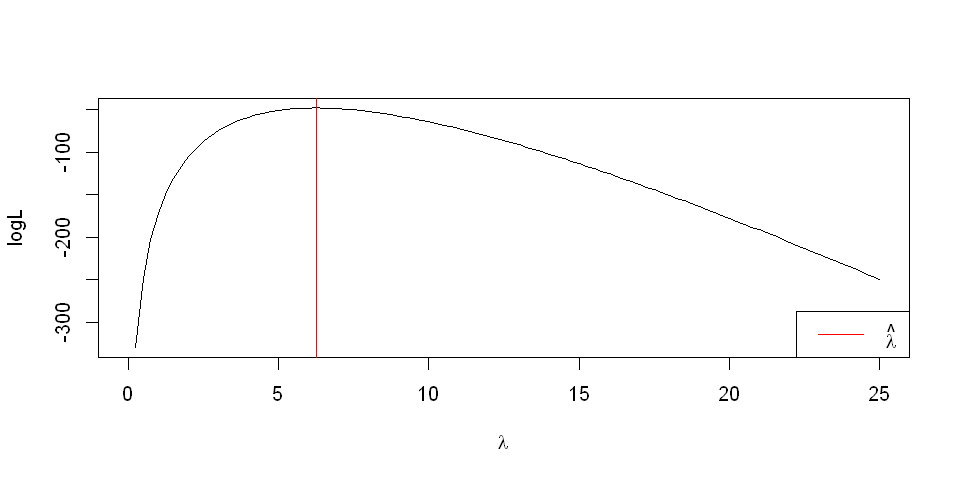

```r
curve(loglikpois.lambda(x), from = lambda_est.min, to = lambda_est.max, xlab=expression(lambda), ylab="logL")

# Naudojant standartinę R optimizavimo f-ją, randamas loglikpois() maksimumas (lambda did. tik. įvertis)
optimize.interval = c(lambda_est.min, lambda_est.max)
lambda_est.numerical = optimize(f = loglikpois.lambda, interval = optimize.interval, maximum = T)$maximum
abline(v = lambda_est.numerical, col = "red")
legend("bottomright", legend=c(NA, expression(hat(lambda)), NA), col="red", lty=c(NA,1,NA))

# Gautas įvertis lyginamas su analitiniu būdų gautuoju įverčiu
cat("Tikroji lambda parametro reikšmė:", X.lambda, "\n")
cat("Skaitiniu būdu gautas lambda did. tik. įvertis:", lambda_est.numerical, "\n")
cat("Analiziniu būdu gautas lambda did. tik. įvertis:", lambda_est.analytical, "\n")
```

Matome, jog analiziniu ir skaitiniu būdais gauti did. tik. įverčiai sutampa.

[figure not shown]

##### Apibrėžiama Niutono metodo funkcija skirta parametrų įverčiams rasti

```r
estimate_dist_parameter = function(x, loglikfun.param, use_modified_newton_method=F, epsilon=1e-3, parameter.initial=1) {
    iterations = 0
    parameter = parameter.initial

    repeat {
        iterations = iterations + 1
        derivative.first = fderiv(f = loglikfun.param, x = parameter, n = 1)
        derivative.second.x = ifelse(use_modified_newton_method, parameter.initial, parameter)
        derivative.second = fderiv(f = loglikfun.param, x = derivative.second.x, n = 2)
        parameter.new = parameter - derivative.first / derivative.second

        if (abs(parameter - parameter.new) < epsilon) {
            parameter = parameter.new
            break
        }
        parameter = parameter.new
    }
    return(data.frame(parameter=parameter,
                      iterations=iterations,
                      epsilon=epsilon,
                      use_modified_newton_method=use_modified_newton_method))
}
```

```r
print_result = function(res) {
    cat("Parametro d.t.įvertinys: ", res$parameter, ", jam rasti prireikė ", res$iterations,
        " iteracijų (", ifelse(res$use_modified_newton_method, "Modifikuotas ", ""),
        "Niutono metodas, epsilon=", res$epsilon, ")\n", sep="")
}
```

##### a) Gaunamas Puasono dėsnio parametro $\lambda$ didžiausio tikėtinumo įvertis

```r
X.lambda = 6
x.size = 100
x = rpois(n = x.size, lambda = X.lambda)
# Pastaba: funkcija "loglikpois.lambda" apibrėžta 4.2. užduotyje

cat("Parametro tikroji reikšmė:", X.lambda, "\n")
print_result(estimate_dist_parameter(x, loglikpois.lambda))
print_result(estimate_dist_parameter(x, loglikpois.lambda, use_modified_newton_method = T))
```

```
Parametro tikroji reikšmė: 6
Parametro d.t.įvertinys: 5.76, jam rasti prireikė 7 iteracijų (Niutono metodas, epsilon=0.001)
Parametro d.t.įvertinys: 5.72885, jam rasti prireikė 136 iteracijų (Modifikuotas Niutono metodas, epsilon=0.001)
```

##### b) Gaunamas normaliojo dėsnio parametro $\sigma^2$ didžiausio tikėtinumo įvertis

```r
X.mean = 5
X.variance = 10
X.sd = sqrt(X.variance)
x.size = 100
x = rnorm(n = x.size, mean = X.mean, sd = X.sd)
logliknorm = function(X.mean, X.sd)
    sum(Vectorize(function(x.i) dnorm(x.i, mean = X.mean, sd = X.sd, log = T))(x))
logliknorm.variance = Vectorize(function(X.variance) logliknorm(X.mean, sqrt(X.variance)))

cat("Parametro tikroji reikšmė:", X.variance, "\n")
print_result(estimate_dist_parameter(x, logliknorm.variance))
print_result(estimate_dist_parameter(x, logliknorm.variance, use_modified_newton_method = T))
```

```
Parametro tikroji reikšmė: 10
Parametro d.t.įvertinys: 11.41503, jam rasti prireikė 11 iteracijų (Niutono metodas, epsilon=0.001)
Parametro d.t.įvertinys: 9.462915, jam rasti prireikė 1684 iteracijų (Modifikuotas Niutono metodas, epsilon=0.001)
```